# CSSS 594, Quiz 4

Neal MArquez

11/22/2017

# Instructions

Submit a completed copy of this quiz sheet *BOTH* as a `.Rmd` and `.html` file to Canvas in the Quiz 4 assignment page.

*IMPORTANT!* Most chunks have `eval=FALSE` in the options. Once you have the code in the chunk working, change it to `eval=TRUE`. That way, the results of code that works will be included in your document if you compile as you go along, while results of code that doesn’t yet work won’t. When you are done with the quiz, all code chunks that part of your answers should have `eval=TRUE`.

# Background

We are returning to the cows data we used at the beginning of the quarter. Cows were fed one of three different diets (barley, lupins, or a mixture of the two). The protein content of milk (percentage of protein in their milk) were measured each week. In these problems, we will build several models of the cows’ protein trajectories and use model selection to examine the effect of adding covariates, treating time in different ways and considering the groupings that exist within this dataset.

The code below will read in the data and plot all trajectories to remind you about the data.

```r
# Make sure you have these libraries installed on your computer so they load in properly!
rm(list=ls())
library(dplyr)
library(ggplot2)
library(nlme)
library(lcmm)
options(digits=3) # keep the printed output narrow

# change directories to your own computer
milk_long <- read.table("./milk_long.csv",
                       header=TRUE,
                       sep=",")
```

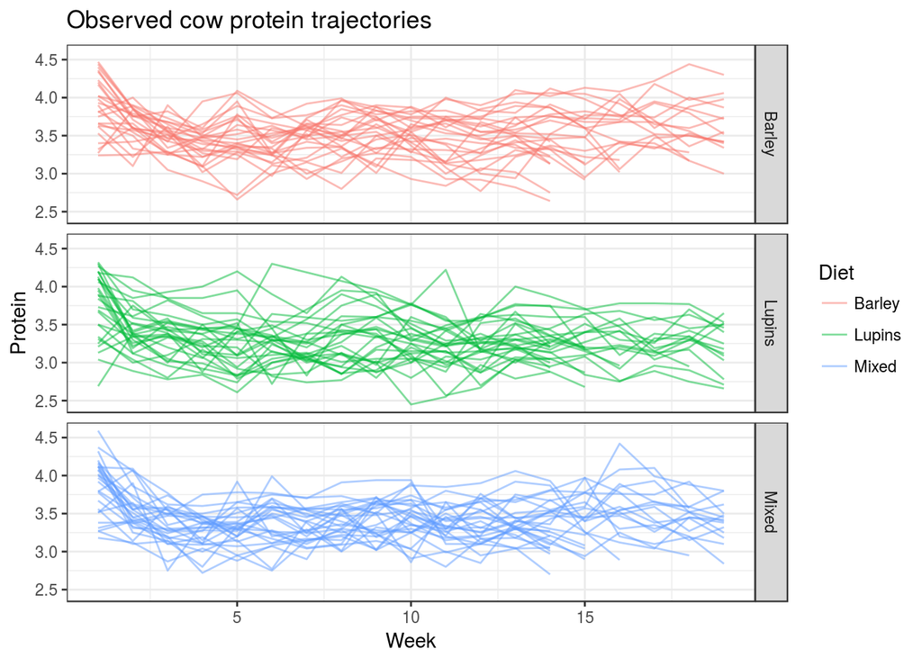

```r
ggplot(data=milk_long, aes(x=Week, y=Protein, group=Cow, color=Diet)) +
    geom_line(alpha=0.5) +
    facet_grid( Diet ~ .) +
    theme_bw() +
    ggtitle("Observed cow protein trajectories")
```

# Question 1

*We will fit the following two-level linear mixed model to the milk data*:

- $\text{Protein}_{ij} = \pi_{0i} + \pi_{1i} \cdot \text{Week}_{ij} + \varepsilon_{ij}$
- $\pi_{0i} = \gamma_{00} + \zeta_{0i}$
- $\pi_{1i} = \gamma_{10} + \zeta_{1i}$
- $\varepsilon_{ij} \sim N(0, \sigma_\varepsilon^2)$
- $\left[ \begin{array}{c} \zeta_{0i} \\ \zeta_{1i} \end{array} \right] \sim N\left( \left[ \begin{array}{c} 0 \\ 0 \end{array} \right], \left[ \begin{array}{cc} \sigma_0^2 & \sigma_{01} \\ \sigma_{01} & \sigma_1^2 \end{array} \right]\right)$

*Fill in the call to the `lme` command below to successfully create the model `milk_linear1` and print its summary.*

```r
milk_linear1 <- lme(Protein ~ 1 + Week, data=milk_long,
                    random= ~ 1 + Week | Cow, method="ML")
summary(milk_linear1)
```

```
## Linear mixed-effects model fit by maximum likelihood
##  Data: milk_long
##   AIC BIC logLik
##   369 400   -178
##
## Random effects:
##  Formula: ~1 + Week | Cow
##  Structure: General positive-definite, Log-Cholesky parametrization
##             StdDev Corr
## (Intercept) 0.2674 (Intr)
## Week        0.0251 -0.731
## Residual    0.2458
##
## Fixed effects: Protein ~ 1 + Week
##             Value Std.Error   DF t-value p-value
## (Intercept)  3.52    0.0333 1257     106   0e+00
## Week        -0.01    0.0032 1257      -4   1e-04
##  Correlation:
##      (Intr)
## Week -0.757
##
## Standardized Within-Group Residuals:
##     Min      Q1     Med      Q3     Max
## -3.1413 -0.5945 -0.0266  0.5455  3.6434
##
## Number of Observations: 1337
## Number of Groups: 79
```

# Question 2

*We will then fit the following two-level linear mixed model to the milk data*:

- $\text{Protein}_{ij} = \pi_{0i} + \pi_{1i} \cdot \text{Week}_{ij} + \varepsilon_{ij}$
- $\pi_{0i} = \gamma_{00} + \gamma_{01} \cdot \text{I(Diet=Lupins)}_i + \gamma_{02} \cdot \text{I(Diet=Mixed)}_i + \zeta_{0i}$
- $\pi_{1i} = \gamma_{10} + \gamma_{11} \cdot \text{I(Diet=Lupins)}_i + \gamma_{12} \cdot \text{I(Diet=Mixed)}_i + \zeta_{1i}$
- $\varepsilon_{ij} \sim N(0, \sigma_\varepsilon^2)$
- $\left[ \begin{array}{c} \zeta_{0i} \\ \zeta_{1i} \end{array} \right] \sim N\left( \left[ \begin{array}{c} 0 \\ 0 \end{array} \right], \left[ \begin{array}{cc} \sigma_0^2 & \sigma_{01} \\ \sigma_{01} & \sigma_1^2 \end{array} \right]\right)$

*Fill in the call to the `lme` command below to successfully create the model `milk_linear2` and print its summary.*

```r
milk_linear2 <- lme(Protein ~ 1 + Week + Diet + Diet*Week, data=milk_long,
                    random= ~ 1 + Week | Cow, method="ML")
summary(milk_linear2)
```

```
## Linear mixed-effects model fit by maximum likelihood
##  Data: milk_long
##   AIC BIC logLik
##   361 413   -170
##
## Random effects:
##  Formula: ~1 + Week | Cow
##  Structure: General positive-definite, Log-Cholesky parametrization
##             StdDev Corr
## (Intercept) 0.2629 (Intr)
## Week        0.0247 -0.781
## Residual    0.2458
##
## Fixed effects: Protein ~ 1 + Week + Diet + Diet * Week
##                 Value Std.Error   DF t-value p-value
## (Intercept)      3.59    0.0584 1255    61.5   0.000
## Week            -0.01    0.0055 1255    -1.6   0.105
## DietLupins      -0.12    0.0810   76    -1.5   0.131
## DietMixed       -0.08    0.0810   76    -1.0   0.307
## Week:DietLupins -0.01    0.0077 1255    -1.1   0.254
## Week:DietMixed   0.00    0.0077 1255    -0.2   0.866
##  Correlation:
##                 (Intr) Week   DtLpns DitMxd Wk:DtL
## Week            -0.798
## DietLupins      -0.720  0.575
## DietMixed       -0.721  0.575  0.519
## Week:DietLupins  0.574 -0.719 -0.798 -0.414
## Week:DietMixed   0.575 -0.720 -0.414 -0.798  0.518
##
## Standardized Within-Group Residuals:
##     Min      Q1     Med      Q3     Max
## -3.1305 -0.5967 -0.0244  0.5459  3.6154
##
## Number of Observations: 1337
## Number of Groups: 79
```

# Question 3

*What is the interpretation of the estimate of $\gamma_{10}$ in the model `milk_linear1`? Is this the same as the interpretation of the estimate of $\gamma_{10}$ in model `milk_linear2`? If not, what are the differences?*

In `milk_linear1` the parameter $\gamma_{10}$ is the across individual average change in Protein count that is associated with a one unit change in week. This is not the same in the `milk_linear2` model where the interpretation of $\gamma_{10}$ is the across individual average change of Protien count associated with a one unit change in week only for cows with a Barley diet.

# Question 4

*Perform a likelihood ratio test to compare the `milk_linear1` and `milk_linear2` models. Which model does the likelihood ratio test favor, using a $p < 0.05$ cutoff? Interpret this comparison in the context of this study (1-2 sentences).*

```r
anova(milk_linear1, milk_linear2)
```

```
##              Model df AIC BIC logLik   Test L.Ratio p-value
## milk_linear1     1  6 369 400   -178
## milk_linear2     2 10 361 413   -170 1 vs 2    16.1  0.0028
```

Using a $p < 0.05$ cutoff the anova test favors the `milk_linear2` model over the `milk_linear1` model. In the context of this study this means that the inclusion of indicator variables, in `milk_linear2`, describing an individuals cows diet and how that cows diet intereacts with chnages over time produces a more descriptive explanation of the variance in milk protein levels, even when penalized for the inclusion of more paramters in the model when compared with `milk_linear1`.

# Question 5

*Using your R output from Question 4, compare models `milk_linear1` and `milk_linear2` by the AIC and BIC. Which model is selected by each score? Interpret this comparison in the context of this study (1-2 sentences). Does the fact that AIC and BIC use a different penalty for overfitting make a difference in this case?*

When looking at `AIC` and `BIC` as the selection criteria, `AIC` favors `milk_linear2` while BIC favors `milk_linear1`. This can be interpreted as `AIC` favoring the inclusion of the Diet paramters because it more accurately descirbes the variance of milk protein while BIC states that the model with fewer paramters should be selected because the diet paramters due not have a sufficiently non-zero effect on mil protein outcomes..

# Question 6

*Now we fit a model with a quadratic curvilinear form for the population average trajectories as given below:*

- $\text{Protein}_{ij} = \pi_{0i} + \pi_{1i} \cdot \text{Week}_{ij} + \pi_{2i} \cdot \text{Week}_{ij}^2 + \varepsilon_{ij}$
- $\pi_{0i} = \gamma_{00} + \gamma_{01} \cdot \text{I(Diet=Lupins)}_i + \gamma_{02} \cdot \text{I(Diet=Mixed)}_i + \zeta_{0i}$
- $\pi_{1i} = \gamma_{10} + \gamma_{11} \cdot \text{I(Diet=Lupins)}_i + \gamma_{12} \cdot \text{I(Diet=Mixed)}_i + \zeta_{1i}$
- $\pi_{2i} = \gamma_{20} + \gamma_{21} \cdot \text{I(Diet=Lupins)}_i + \gamma_{22} \cdot \text{I(Diet=Mixed)}_i + \zeta_{2i}$
- $\varepsilon_{ij} \sim N(0, \sigma_\varepsilon^2)$
- $\left[ \begin{array}{c} \zeta_{0i} \\ \zeta_{1i} \\ \zeta_{2i} \end{array} \right] \sim N\left( \left[ \begin{array}{c} 0 \\ 0 \\0 \end{array} \right], \left[ \begin{array}{ccc} \sigma_0^2 & \sigma_{01} & \sigma_{02} \\ \sigma_{01} & \sigma_1^2 & \sigma_{12} \\ \sigma_{02} & \sigma_{12} & \sigma_2^2 \end{array} \right]\right)$

*Fill in the call to the `lme` command below to successfully create the model `milk_quad_diet` and print its summary.*

```r
milk_long <- milk_long %>% mutate(Week2=Week^2)
milk_quad_diet <- lme(Protein ~ 1 + Week + Week2 +
                          Diet + Diet*Week + Diet*Week2, data=milk_long,
                    random= ~ 1 + Week + Week2 | Cow, method="ML")
summary(milk_quad_diet)
```

```
## Linear mixed-effects model fit by maximum likelihood
##  Data: milk_long
##   AIC BIC logLik
##   263 346   -115
##
## Random effects:
##  Formula: ~1 + Week + Week2 | Cow
##  Structure: General positive-definite, Log-Cholesky parametrization
##             StdDev  Corr
## (Intercept) 0.29404 (Intr) Week
## Week        0.06079 -0.713
## Week2       0.00328  0.510 -0.934
## Residual    0.22880
##
## Fixed effects: Protein ~ 1 + Week + Week2 + Diet + Diet * Week + Diet * Week2
##                  Value Std.Error   DF t-value p-value
## (Intercept)       3.70    0.0698 1252    53.1  0.0000
## Week             -0.04    0.0154 1252    -2.9  0.0040
## Week2             0.00    0.0008 1252     2.3  0.0236
## DietLupins       -0.14    0.0968   76    -1.5  0.1425
## DietMixed        -0.10    0.0968   76    -1.0  0.3059
## Week:DietLupins   0.00    0.0214 1252    -0.1  0.9191
## Week:DietMixed    0.00    0.0214 1252     0.2  0.8297
## Week2:DietLupins  0.00    0.0012 1252    -0.3  0.7455
## Week2:DietMixed   0.00    0.0012 1252    -0.3  0.7444
##  Correlation:
##                  (Intr) Week   Week2  DtLpns DitMxd Wk:DtL Wk:DtM Wk2:DL
## Week             -0.766
## Week2             0.591 -0.945
## DietLupins       -0.721  0.552 -0.426
## DietMixed        -0.721  0.552 -0.426  0.520
## Week:DietLupins   0.551 -0.719  0.679 -0.766 -0.397
## Week:DietMixed    0.552 -0.720  0.681 -0.398 -0.766  0.518
## Week2:DietLupins -0.424  0.677 -0.716  0.591  0.305 -0.945 -0.488
## Week2:DietMixed  -0.425  0.680 -0.720  0.306  0.591 -0.489 -0.945  0.515
##
## Standardized Within-Group Residuals:
##       Min        Q1       Med        Q3       Max
## -3.405023 -0.601689  0.000284  0.559893  3.313366
##
## Number of Observations: 1337
## Number of Groups: 79
```

# Question 7

*Perform a likelihood ratio test to compare the `milk_linear1`, `milk_linear2` and `milk_quad_diet` models. Which model does the likelihood ratio test favor, using a $p < 0.05$ cutoff? Interpret this comparison in the context of this study (1-2 sentences).*

```r
# Run one command in R here
anova(milk_linear1, milk_linear2, milk_quad_diet)
```

```
##                Model df AIC BIC logLik   Test L.Ratio p-value
## milk_linear1       1  6 369 400   -178
## milk_linear2       2 10 361 413   -170 1 vs 2    16.1  0.0028
## milk_quad_diet     3 16 263 346   -116 2 vs 3   109.7  <.0001
```

Using a $p < 0.05$ cutoff the likelihood ratio test prefers the `milk_quad_diet` over the other two models. This means that the inclusion of diet parameters that interect with a quadratic fit over time, weeks in our case, better describes the variation in milk proteins observed than a linear model, or a linear model that includes diet and an interaction between diet and linear change over time.

# Question 8

*Now use the `hlme` function introduced in Lab 9 to fit a model that assumes **three latent groups** with each having a **linear trajectory** over time, with no random effects and no covariates. You don’t need to specify initial parameter values.*

*Fill in the call to the `hlme` command below to successfully create the model `milk_linear_3` and print its summary.*

```r
milk_linear_3 <- hlme(fixed = Protein ~ Week,
              subject = "Cow",
              mixture = ~ Week,
              ng = 3,
              data = milk_long)
```

```
## Be patient, hlme is running ...
## The program took 0.7 seconds
```

```r
summary(milk_linear_3)
```

```
## Heterogenous linear mixed model
##      fitted by maximum likelihood method
##
## hlme(fixed = Protein ~ Week, mixture = ~Week, subject = "Cow",
##     ng = 3, data = milk_long)
##
## Statistical Model:
##      Dataset: milk_long
##      Number of subjects: 79
##      Number of observations: 1337
##      Number of latent classes: 3
##      Number of parameters: 9
##
## Iteration process:
##      Convergence criteria satisfied
##      Number of iterations:  12
##      Convergence criteria: parameters= 8.4e-09
##                          : likelihood= 8.3e-08
##                          : second derivatives= 6.4e-13
##
## Goodness-of-fit statistics:
##      maximum log-likelihood: -254.38
##      AIC: 526.77
##      BIC: 548.09
##
##
## Maximum Likelihood Estimates:
##
## Fixed effects in the class-membership model:
## (the class of reference is the last class)
##
##                      coef      Se    Wald p-value
## intercept class1 -0.51566 0.37822  -1.363 0.17275
## intercept class2  0.67495 0.29892   2.258 0.02395
##
## Fixed effects in the longitudinal model:
##
##                      coef      Se    Wald p-value
## intercept class1  3.17293 0.04503  70.461 0.00000
## intercept class2  3.48863 0.02798 124.679 0.00000
## intercept class3  3.65218 0.03924  93.082 0.00000
## Week class1      -0.00576 0.00418  -1.378 0.16810
## Week class2      -0.00999 0.00275  -3.630 0.00028
## Week class3      -0.00012 0.00339  -0.036 0.97154
##
##                              coef      Se
## Residual standard error:  0.27828 0.00544
```

# Question 9

*Use the `hlme` function to fit a model that assumes **three latent groups** with each having a **quadratic trajectory** over time, with no random effects and no covariates. You don’t need to specify initial parameter values.*

*Fill in the call to the `hlme` command below to successfully create the model `milk_quad_3` and print its summary.*

```r
milk_quad_3 <- hlme(fixed = Protein ~ Week + Week2,
              subject = "Cow",
              mixture = ~ Week + Week2,
              ng = 3,
              data = milk_long)
summary(milk_quad_3)
```

[output not shown]

# Question 10

*For a given group-based trajectory model, the function below produces a table of most likely class numbers for all cows, crossed with those cows’ diet. Use the function to generate such a table for the group-based models `milk_linear_3` and `milk_quad_3`. Compare the two models’ abilities to discern between the 3 diet groups. Interpret this comparison in the context of this study (1-2 sentences).*

```r
tabResultsByDietGroup <- function(hlme_model) {
 return( table( milk_long %>%
           select(Cow, Diet) %>%
           left_join(hlme_model$pprob, by="Cow") %>%
           select(Cow, Diet, class) %>%
           distinct() %>%
           select(-Cow) ) ) }
# Use the above function to generate the tables for the two hlme models
tabResultsByDietGroup(milk_linear_3)
tabResultsByDietGroup(milk_quad_3)
```

[output not shown]